# 4T1 Mets RNA Seq - Differential Analysis

Andrew Chen

September 12, 2023

```r
library(Biobase)
library(SummarizedExperiment)
library(tidyverse)
library(ggplot2)
library(DESeq2)
library(reactable)
library(cba)
library(pheatmap)
library(vennr)

PATH <- file.path(Sys.getenv("MLAB"),"projects/brcameta/exosome/4t1_brca_brain_mets/")
DPATH <- file.path(Sys.getenv("CBM"),"otherStudies/RNAseq/2022-06-03-DenisExosomeBrCaBrainMets/")
```

# Load Data

```r
dat <- readRDS(file.path(PATH,"data/4T1_mets_sExp.rds"))
dat_pool <- readRDS(file.path(PATH,"data/4T1_mets_control_IS_pool_sExp.rds"))
```

# DESeq Result Tables

> DESeq2 performs an internal normalization where geometric mean is calculated for each gene across all samples. The counts for a gene in each sample is then divided by this mean. The median of these ratios in a sample is the size factor for that sample. This procedure corrects for library size and RNA composition bias, which can arise for example when only a small number of genes are very highly expressed in one experiment condition but not in the other.

```r
dds <- DESeq2::DESeqDataSetFromMatrix(countData=round(assays(dat)$counts),
                                      colData=dat@colData,
                                      design=~condition)
```

```r
# Map EnsemblID to GeneID
ensembl_symbol <- function(ensembl_id, sExp) {
  return(unlist(rowData(sExp)[ensembl_id,"mgi_symbol"]))
}
symbol_ensembl <- function(gene_id, sExp) {
  return(rownames(sExp)[rowData(sExp)$mgi_symbol == gene_id])
}
```

## IR IS

```r
dds <- DESeq(dds)
```

Summary of Different comparisons

```r
lfcs <- seq(0,0.5,0.1)
comp_df <- data.frame(lfcs = lfcs)
for (i in seq_along(lfcs)) {
  lfc <- lfcs[i]
  dds_res <- results(dds, alpha=0.05, lfcThreshold = lfc, contrast=c("condition", "IR", "IS"))
  nPos <- sum((dds_res$padj < 0.05) & (dds_res$log2FoldChange > lfc), na.rm=TRUE)
  nNeg <- sum((dds_res$padj < 0.05) & (dds_res$log2FoldChange < -lfc), na.rm=TRUE)
  comp_df$nPos[i] = nPos
  comp_df$nNeg[i] = nNeg
}

comp_df
```

| lfcs | nPos | nNeg |
| --- | --- | --- |
| 0.0 | 273 | 319 |
| 0.1 | 20 | 39 |
| 0.2 | 0 | 6 |
| 0.3 | 0 | 3 |
| 0.4 | 0 | 1 |
| 0.5 | 0 | 1 |

```r
dds_ir_is_res <- results(dds, alpha=0.05, lfcThreshold = 0.1, contrast=c("condition", "IR", "IS"))
dds_ir_is_res_df <- dds_ir_is_res[which(with(dds_ir_is_res, padj<0.05 & (log2FoldChange <= -0.1 | log2FoldChange >= 0.1))),] %>% as.data.frame
dds_ir_is_res_df_symbol <- unlist(lapply(rownames(dds_ir_is_res_df), ensembl_symbol, sExp=dat))
dds_ir_is_res_df <- dds_ir_is_res_df[dds_ir_is_res_df_symbol != "",]
rownames(dds_ir_is_res_df) <- dds_ir_is_res_df_symbol[dds_ir_is_res_df_symbol != ""]
write.csv(dds_ir_is_res_df[order(dds_ir_is_res_df$log2FoldChange),], file=file.path(PATH, "data/dds_ir_is_diffanal.csv"))
```

Table of Results

```r
reactable(dds_ir_is_res_df, searchable = TRUE)
```

|  | baseMean | log2FoldChange | lfcSE | stat | pvalue | padj |
| --- | --- | --- | --- | --- | --- | --- |
| Rasa4 | 245.399000801777 | -1.15048552282215 | 0.265041198172694 | -3.96348013088016 | 7.3865013896601e-05 | 0.028829079092407 |
| Plekho1 | 714.428180410435 | -0.880020641438125 | 0.188335933436136 | -4.14164534195292 | 3.4482325502915e-05 | 0.0206907745947691 |
| Plgrkt | 239.727016314211 | -0.554422325308939 | 0.120286026257158 | -3.77784801318013 | 0.000158189365516553 | 0.0427706528483325 |
| Trpv2 | 391.983717612054 | -0.86822092076684 | 0.197140958789815 | -3.89681031015929 | 9.74678997961814e-05 | 0.0324477773157307 |
| Pkib | 34.6299762273982 | -1.91542026157468 | 0.417549869319136 | -4.34779267093279 | 1.375145030501e-05 | 0.0156346466031236 |
| Myo1g | 100.67048268093 | -1.28285896467133 | 0.312628613293818 | -3.78359150241837 | 0.000154581457304323 | 0.0427706528483325 |
| Id2 | 443.835643708182 | -1.35375995131326 | 0.255687654911318 | -4.90348253906944 | 9.41523155510032e-07 | 0.002017684122258 |
| Pxdn | 632.739277888655 | 0.919422525397517 | 0.203583137923133 | 4.0250019415012 | 5.6974845419183e-05 | 0.0251376369450931 |
| Ppp1r13b | 231.252075562431 | 0.610335005798533 | 0.129355068187541 | 3.94522621300497 | 7.97246784463808e-05 | 0.028829079092407 |
| Ly86 | 58.6841685432435 | -1.64061540772494 | 0.377136106721319 | -4.08503821370614 | 4.40695632009757e-05 | 0.0216145082496093 |

[output cut: 49 more lines]

## IR Control

```r
lfcs <- seq(0,1,0.1)
comp_df <- data.frame(lfcs = lfcs)
for (i in seq_along(lfcs)) {
  lfc <- lfcs[i]
  dds_res <- results(dds, alpha=0.05, lfcThreshold = lfc, contrast=c("condition", "IR", "C"))
  nPos <- sum((dds_res$padj < 0.05) & (dds_res$log2FoldChange > lfc), na.rm=TRUE)
  nNeg <- sum((dds_res$padj < 0.05) & (dds_res$log2FoldChange < -lfc), na.rm=TRUE)
  comp_df$nPos[i] = nPos
  comp_df$nNeg[i] = nNeg
}

comp_df
```

| lfcs | nPos | nNeg |
| --- | --- | --- |
| 0.0 | 1064 | 865 |
| 0.1 | 566 | 366 |
| 0.2 | 352 | 148 |
| 0.3 | 254 | 82 |
| 0.4 | 193 | 52 |
| 0.5 | 146 | 23 |
| 0.6 | 114 | 13 |
| 0.7 | 90 | 8 |
| 0.8 | 78 | 4 |
| 0.9 | 65 | 3 |

[output cut: 1 more lines]

```r
dds_ir_c_res <- results(dds, alpha=0.05, lfcThreshold = 0.4, contrast=c("condition", "IR", "C"))
summary(dds_ir_c_res)
```

```
##
## out of 15002 with nonzero total read count
## adjusted p-value < 0.05
## LFC > 0.40 (up)    : 193, 1.3%
## LFC < -0.40 (down) : 52, 0.35%
## outliers [1]       : 1, 0.0067%
## low counts [2]     : 0, 0%
## (mean count < 4)
## [1] see 'cooksCutoff' argument of ?results
## [2] see 'independentFiltering' argument of ?results
```

```r
dds_ir_c_res_df <- dds_ir_c_res[which(with(dds_ir_c_res, padj<0.05 & (log2FoldChange < -0.4 | log2FoldChange > 0.4))),] %>% as.data.frame
dds_ir_c_res_df_symbol <- unlist(lapply(rownames(dds_ir_c_res_df), ensembl_symbol, sExp=dat))
dds_ir_c_res_df <- dds_ir_c_res_df[dds_ir_c_res_df_symbol != "",]
rownames(dds_ir_c_res_df) <- dds_ir_c_res_df_symbol[dds_ir_c_res_df_symbol != ""]
write.csv(dds_ir_c_res_df[order(dds_ir_c_res_df$log2FoldChange),], file=file.path(PATH, "data/dds_IR_C_diffanal.csv"))
```

Table of Results

```r
reactable(dds_ir_c_res_df, searchable = TRUE)
```

|  | baseMean | log2FoldChange | lfcSE | stat | pvalue | padj |
| --- | --- | --- | --- | --- | --- | --- |
| Bcl6b | 132.826043089269 | 3.25000847378688 | 0.635031714695532 | 4.48797817153641 | 7.19022939272183e-06 | 0.00102724410590686 |
| Acvrl1 | 463.953601584693 | 1.19444169183447 | 0.19270995627967 | 4.12247352016177 | 3.74825709344118e-05 | 0.00417711300692548 |
| Cd52 | 18.6820981512192 | -2.63633889042276 | 0.643791546193669 | -3.47370030508293 | 0.000513334048560671 | 0.0361341805742664 |
| Icam2 | 41.1310143844524 | 2.37744873049039 | 0.451130311720068 | 4.38332047108691 | 1.16883975344382e-05 | 0.0015246752296879 |
| N4bp3 | 103.942682253753 | 1.83881000018922 | 0.307658246962769 | 4.67665019349647 | 2.91599047779156e-06 | 0.000497076967697173 |
| Esam | 450.948934365916 | 1.95647639974347 | 0.251613890893036 | 6.18597166563092 | 6.17210941456138e-10 | 5.7867383329897e-07 |
| Peg3 | 3240.04231213808 | 1.02711278513229 | 0.12763060601312 | 4.91349845246227 | 8.94654392231981e-07 | 0.000192691050408479 |
| Jag2 | 51.4995379184382 | 1.85028140644739 | 0.366531555082108 | 3.95677094192478 | 7.59697127716859e-05 | 0.0078056278170415 |
| St8sia6 | 87.3647800658864 | 2.37919852650786 | 0.407196553250266 | 4.86054832908035 | 1.17061060732246e-06 | 0.000237301752978976 |
| Pgf | 278.411781421091 | 1.80047332800544 | 0.341823603590565 | 4.09706443117052 | 4.18422470276404e-05 | 0.00461526137986496 |

[output cut: 235 more lines]

## Control IS

```r
lfcs <- seq(0,0.5,0.1)
comp_df <- data.frame(lfcs = lfcs)
for (i in seq_along(lfcs)) {
  lfc <- lfcs[i]
  dds_res <- results(dds, alpha=0.05, lfcThreshold = lfc, contrast=c("condition", "C", "IS"))
  nPos <- sum((dds_res$padj < 0.05) & (dds_res$log2FoldChange > lfc), na.rm=TRUE)
  nNeg <- sum((dds_res$padj < 0.05) & (dds_res$log2FoldChange < -lfc), na.rm=TRUE)
  comp_df$nPos[i] = nPos
  comp_df$nNeg[i] = nNeg
}

comp_df
```

| lfcs | nPos | nNeg |
| --- | --- | --- |
| 0.0 | 546 | 700 |
| 0.1 | 203 | 265 |
| 0.2 | 105 | 127 |
| 0.3 | 53 | 74 |
| 0.4 | 25 | 34 |
| 0.5 | 15 | 10 |

```r
dds_c_is <- results(dds, alpha=0.05, lfcThreshold = 0.3, contrast=c("condition", "C", "IS"))
summary(dds_c_is)
```

```
##
## out of 15002 with nonzero total read count
## adjusted p-value < 0.05
## LFC > 0.30 (up)    : 53, 0.35%
## LFC < -0.30 (down) : 74, 0.49%
## outliers [1]       : 1, 0.0067%
## low counts [2]     : 0, 0%
## (mean count < 4)
## [1] see 'cooksCutoff' argument of ?results
## [2] see 'independentFiltering' argument of ?results
```

```r
dds_c_is_df <- as.data.frame(dds_c_is[which(dds_c_is$padj < 0.05, dds_c_is$log2FoldChange > 0.3),])
dds_c_is_df_symbol <- unlist(lapply(rownames(dds_c_is_df), ensembl_symbol, sExp=dat_pool))
dds_c_is_df <- dds_c_is_df[dds_c_is_df_symbol != "",]
rownames(dds_c_is_df) <- dds_c_is_df_symbol[dds_c_is_df_symbol != ""]
write.csv(dds_c_is_df[order(dds_c_is_df$log2FoldChange),], file=file.path(PATH,"data/dds_c_isontrol_pool_diffanal.csv"))
```

Table of Results

```r
reactable(dds_c_is_df, searchable = TRUE)
```

|  | baseMean | log2FoldChange | lfcSE | stat | pvalue | padj |
| --- | --- | --- | --- | --- | --- | --- |
| Bcl6b | 132.826043089269 | -2.5413895828914 | 0.635666131744916 | -3.52604845681922 | 0.000421809783295296 | 0.04982337448199 |
| Slc5a5 | 2573.41322981129 | 0.983290963045504 | 0.130101456443983 | 5.25198550209701 | 1.50468308776427e-07 | 0.000112858754997759 |
| Esam | 450.948934365916 | -1.21198734353275 | 0.252165204162254 | -3.61662643568355 | 0.000298467561910379 | 0.0382676230445949 |
| Peg3 | 3240.04231213808 | -0.887107882871865 | 0.127615773671674 | -4.60059024037543 | 4.21295456171539e-06 | 0.00175551476056368 |
| Apoe | 19493.9921615651 | -0.779332088689703 | 0.131659945930121 | -3.64068270956233 | 0.000271916065463246 | 0.0364197580179835 |
| Edar | 90.9523313051817 | -0.981423310844185 | 0.174245005106049 | -3.9107193370017 | 9.2021652249438e-05 | 0.0181633790183397 |
| Slc25a18 | 56.9991905694627 | -1.55739590545308 | 0.312511532287924 | -4.02351841625675 | 5.73350984984647e-05 | 0.0129617915863313 |
| Tyrp1 | 577.367104610541 | -2.95211931104285 | 0.398851092627762 | -6.64939713106919 | 2.94295948355625e-11 | 7.35788920213789e-08 |
| Htra1 | 3722.89891577647 | 1.06872730395184 | 0.217103613537888 | 3.5408314556574 | 0.000398868287023958 | 0.0476803280296943 |
| Slc5a6 | 739.092515128343 | -0.825579008288269 | 0.111292778660159 | -4.72248976632314 | 2.32974816020099e-06 | 0.00109214225472422 |

[output cut: 117 more lines]

> No significantly upregulated genes if IS and C are pooled given the same significance and logFC thresholds

# Signature Comparison

```r
# Preparing Signatures
ir_c_up_signatures <- dds_ir_c_res_df %>% dplyr::filter(log2FoldChange > 0) %>% rownames
c_is_up_signatures <- dds_c_is_df %>% dplyr::filter(log2FoldChange > 0) %>% rownames
ir_is_up_signatures <- dds_ir_is_res_df %>% dplyr::filter(log2FoldChange > 0) %>% rownames

ir_c_down_signatures <- dds_ir_c_res_df %>% dplyr::filter(log2FoldChange < 0) %>% rownames
c_is_down_signatures <- dds_c_is_df %>% dplyr::filter(log2FoldChange < 0) %>% rownames
ir_is_down_signatures <- dds_ir_is_res_df %>% dplyr::filter(log2FoldChange < 0) %>% rownames

# Combining labels
all_sigs <- list(ir_c_up=ir_c_up_signatures, c_is_up=c_is_up_signatures, ir_is_up=ir_is_up_signatures,
                 ir_c_down=ir_c_down_signatures, c_is_down=c_is_down_signatures,
                 ir_is_down=ir_is_down_signatures)
ensembl_sigs <- lapply(all_sigs, function(x) unlist(lapply(x, symbol_ensembl, sExp=dat)))
```

```r
vennr(all_sigs)
```

[interactive chart not shown]

# Heatmaps

```r
hcopt <- function(d, HC=NULL, method = "ward.D", members = NULL){
  require("cba")
  if ( is.null(HC) ) {
    HC <- hclust(d,method=method,members=members)
  }
  #optimal leaf ordering
  ORD <- cba::order.optimal(d,merge=HC$merge)
  HC$merge <- ORD$merge
  HC$order <- ORD$order
  HC
}
```

```r
unique_union_de_genes <- unique(unlist(ensembl_sigs))
dat_flt <- dat[unique_union_de_genes,]

dds_annot_col <- colData(dat_flt) %>% data.frame %>% dplyr::select(condition)

dds_annot_row <- data.frame(
  ir_c = dds_ir_c_res %>% as.data.frame() %>% dplyr::filter(row.names(dds_ir_c_res) %in% unique_union_de_genes) %>%
    dplyr::transmute(ir_c=ifelse(log2FoldChange>0,"up","down")),
  c_is = dds_c_is %>% as.data.frame() %>% dplyr::filter(row.names(dds_c_is) %in% unique_union_de_genes) %>%
    dplyr::transmute(c_is=ifelse(log2FoldChange>0,"up","down")),
  ir_is = dds_ir_is_res %>% as.data.frame() %>% dplyr::filter(row.names(dds_ir_is_res) %in% unique_union_de_genes) %>%
    dplyr::transmute(ir_is=ifelse(log2FoldChange>0,"up","down"))
)

dds_annot_colors <- list(condition=c(C="gray",IR="pink", IS="orange"),
                     ir_c=c(up="red",down="blue"),
                     c_is=c(up="red",down="blue"),
                     ir_is=c(up="red",down="blue"))

## use Euclidean distance for columns/samples
## use ward as agglomeration rule
dds.hc01.col <- hcopt(dist(t(assays(dat_flt)$rle_log2)),method="ward.D2")

## use 1-correlation as distance for for rows/genes
## use ward as agglomeration rule
dds.hc01.row <- hcopt(as.dist(1-cor(t(assays(dat_flt)$rle_log2))),method="ward.D2")
```

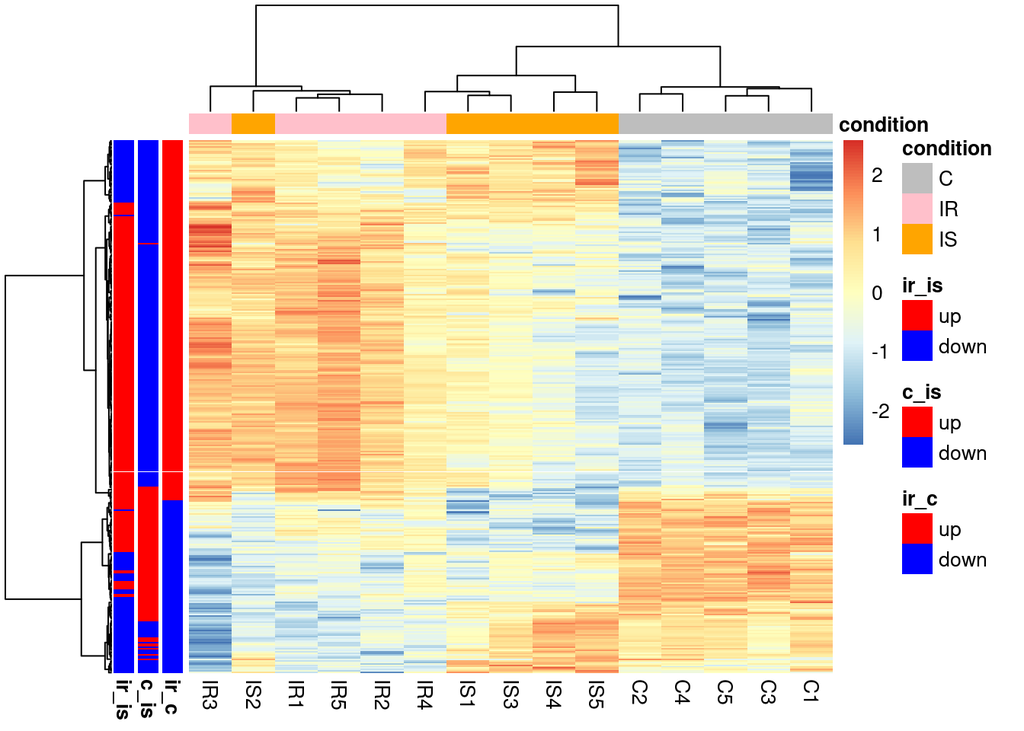

```r
pheatmap(assays(dat_flt)$rle_log2,
         annotation_col = dds_annot_col,
         annotation_row = dds_annot_row,
         annotation_colors = dds_annot_colors,
         cluster_rows=dds.hc01.row,
         cluster_cols=dds.hc01.col,
         show_rownames = FALSE,
         show_colnames = TRUE,
         border_color = NA,
         scale = "row")
```

# Saving Signatures

```r
deseq_list <- list(ir_is = dds_ir_is_res, ir_c = dds_ir_c_res, c_is = dds_c_is)
saveRDS(deseq_list,file=file.path(PATH,"data/deseq_list.rds"))
saveRDS(all_sigs,file=file.path(PATH,"data/signatures_symbol.rds"))
```